# Анализ Git репозиториев

Москва 2025

## Цели

Проект может быть использован для следующих целей:

- анализ благонадёжности пользователя как контрагента на основании его поведенческого профиля;
- детектирование аномалий для предотвращения подмены кода в разрабатываемых проектах.

### Поведенческий профиль

Поведенческий профиль разработчика создаётся на основе его коммитов в репозитории своего профиля (по умолчанию - за год)

## Архитектура

Форма представления проекта: shiny-приложение

Проект разделён на две части: серверную часть (server) и часть графического представления (ui)

- server
  - ETL.R - функции, относящиеся к этапу ETL
  - ML.R - функции, относящиеся к этапу машинного обучения
  - server.R - серверная часть приложения
- ui
  - ui.R - графическая часть приложения
- app.R - подключение серверной части и части графического представления

## Стек технологий

Будут использованы следующие технологии:

- Backend: R
- Frontend: Shiny
- Data processing: dplyr, purrr, httr, dummy
- Визуализация: ggplot2, plotly, heatmaps
- ML: PCA
- Интеграции: GitHub API v3

## Фаза ETL данных

## Работа с репозиториями

GitHub API

[figure not shown]

### Поэтапное формирование ETL

1. Получение списка репозиториев разработчика;
2. На основе полученной информации о репозиториях:
   1. Формирование списка коммитов;
   2. Формирование данных о forks и issues;
   3. Формирование списка используемых ЯП;
   4. Формирование тепловой карты по датам коммитов.

## Фаза аналитики & ML

## Обработка данных

Анализ характера вносимых изменений производится подсчётом количества добавленных, удалённых и изменённых строк.

Создание профиля разработчика происходит на основе данных о коммитах в его репозиториях. Подсчёт аномалий, на данный момент, высчитывается Методом главных компонент.

### Нормализация данных, поэтапно:

1. С помощью dummy, признаки разбиваются с категориальных на некатегориальные;
2. Агрегация по сумме данных о коммитах;
3. Определение главных компонентов;
4. Определение аномалий по порогу выброса.

## Фаза визуализации

## Профиль разработчика

Визуализация простроена на Shiny.

[figure not shown]

## Прототип

Список репозиториев

[figure not shown]

Список коммитов

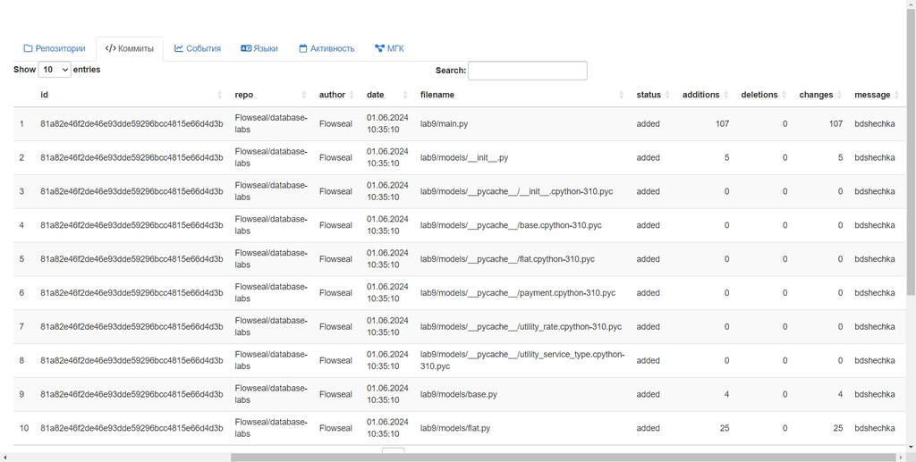

События

[figure not shown]

Распределение используемых языков

[figure not shown]

Тепловая карта активности

[figure not shown]

Подсчёт аномалий

[figure not shown]